**City College of San Francisco**

MATH 108 - Foundations of Data Science

# Lecture 21: Examples

Associated Textbook Sections: [12.3](https://inferentialthinking.com/chapters/12/3/Deflategate.html)

## Set Up the Notebook

```python
from datascience import *
import numpy as np
%matplotlib inline
import matplotlib.pyplot as plots
plots.style.use('fivethirtyeight')
```

## Examples

### Benford's Law

> [Benford's law](https://en.wikipedia.org/wiki/Benford%27s_law), also known as the Newcomb-Benford law, the law of anomalous numbers, or the first-digit law, is an observation that in many real-life sets of numerical data, the leading digit is likely to be small. Benford's law tends to apply most accurately to data that span several orders of magnitude. As a rule of thumb, the more orders of magnitude that the data evenly covers, the more accurately Benford's law applies.

Observe the distribution of the first digits of numbers according to Benford's model.

```python
digits = np.arange(1, 10)
benford_model = np.log10(1 + 1/digits)
```

```python
benford = Table().with_columns(
    'First digit', digits,
    'Benford model prob', benford_model)
benford
```

| First digit | Benford model prob |
| --- | --- |
| 1 | 0.30103 |
| 2 | 0.176091 |
| 3 | 0.124939 |
| 4 | 0.09691 |
| 5 | 0.0791812 |
| 6 | 0.0669468 |
| 7 | 0.0579919 |
| 8 | 0.0511525 |
| 9 | 0.0457575 |

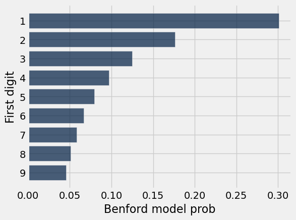

```python
benford.barh('First digit')
```

Use bracket notation to get get the first character of a string.

```python
a_string = 'data science'
a_string[0] # not tested on [ ] notation
```

```
'd'
```

Try the same thing with an integer.

```python
an_integer = 1234
an_integer[0] # :(
```

```
---------------------------------------------------------------------------
TypeError                                 Traceback (most recent call last)
Input In [11], in <cell line: 2>()
      1 an_integer = 1234
----> 2 an_integer[0]

TypeError: 'int' object is not subscriptable
```

Explore the `first_digit` function.

```python
def first_digit(num):
    return int(str(num)[0])
```

```python
first_digit(1234)
```

```
1
```

Load the `countries.csv` data. This data contains county population sizes from the 2010 Census.

```python
counties = Table.read_table('data/counties.csv')
counties = counties.where('SUMLEV', 50).select(5,6,9)\
                                       .relabeled(0,'State')\
                                       .relabeled(1,'County')\
                                       .relabeled(2,'Population')

counties
```

| State | County | Population |
| --- | --- | --- |
| Alabama | Autauga County | 54684 |
| Alabama | Baldwin County | 183216 |
| Alabama | Barbour County | 27336 |
| Alabama | Bibb County | 22879 |
| Alabama | Blount County | 57344 |
| Alabama | Bullock County | 10886 |
| Alabama | Butler County | 20945 |
| Alabama | Calhoun County | 118443 |
| Alabama | Chambers County | 34111 |
| Alabama | Cherokee County | 25968 |

... (3132 rows omitted)

```python
counties.where('County', 'San Francisco County')
```

| State | County | Population |
| --- | --- | --- |
| California | San Francisco County | 805825 |

Apply `first_digit` to add a column to the `countries` table that shows the first digit of the population sizes.

```python
first_digits = counties.apply(first_digit, 'Population')
counties = counties.with_column('First Digit', first_digits)
counties
```

| State | County | Population | First Digit |
| --- | --- | --- | --- |
| Alabama | Autauga County | 54684 | 5 |
| Alabama | Baldwin County | 183216 | 1 |
| Alabama | Barbour County | 27336 | 2 |
| Alabama | Bibb County | 22879 | 2 |
| Alabama | Blount County | 57344 | 5 |
| Alabama | Bullock County | 10886 | 1 |
| Alabama | Butler County | 20945 | 2 |
| Alabama | Calhoun County | 118443 | 1 |
| Alabama | Chambers County | 34111 | 3 |
| Alabama | Cherokee County | 25968 | 2 |

... (3132 rows omitted)

Visually compare the distribution of first digits from the countries data and Benford's proportions.

```python
num_counties = counties.num_rows
```

```python
counties.group('First Digit')
```

| First Digit | count |
| --- | --- |
| 1 | 959 |
| 2 | 590 |
| 3 | 375 |
| 4 | 307 |
| 5 | 217 |
| 6 | 206 |
| 7 | 183 |
| 8 | 154 |
| 9 | 151 |

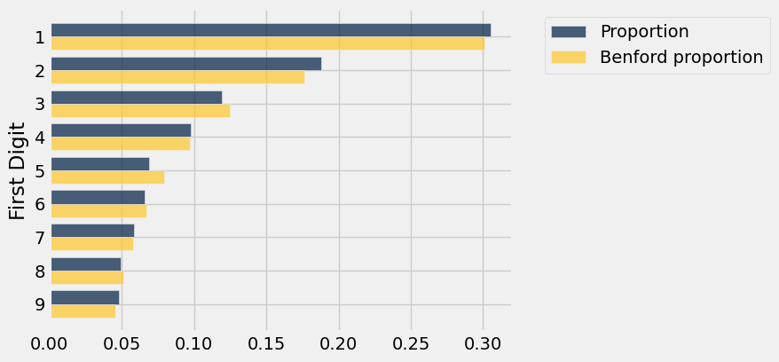

```python
by_digit = counties.group('First Digit')
proportions = by_digit.column('count') / num_counties
by_digit = by_digit.with_columns(
    'Proportion', proportions,
    'Benford proportion', benford_model
)
by_digit.drop('count').barh('First Digit')
```

Test whether or not the distribution of proportions in `countries` is consistent with Benford's model.

Null hypothesis: The difference in the distributions is due to chance.

Alternative hypothesis: The difference in the distributions is not due to chance.

Test statistic: TVD

Fill in the blank with "Bigger" or "Smaller":

Bigger values of the test statistic favor the alternative

Carry out an appropriate hypothesis test based on what we've covered so far.

```python
def tvd(dist1, dist2):
    return sum(abs(dist1 - dist2)) / 2
```

```python
observed_tvd = tvd(proportions, benford_model)
observed_tvd
```

```
0.019227569718005828
```

```python
random_sample_proportions = sample_proportions(num_counties, benford_model)
random_sample_proportions
```

```
array([ 0.30012731,  0.16390834,  0.13208148,  0.09611712,  0.08656906,
        0.06651814,  0.05315086,  0.05633355,  0.04519414])
```

```python
tvd(random_sample_proportions, benford_model)
```

```
0.019711581465758264
```

```python
def simulate_county_first_digits():
    random_sample_proportions = sample_proportions(num_counties, benford_model)
    sim_tvd = tvd(random_sample_proportions, benford_model)
    return sim_tvd
```

```python
simulated_tvds = make_array()

for _ in np.arange(10_000):
    new_tvd = simulate_county_first_digits()
    simulated_tvds = np.append(simulated_tvds, new_tvd)
```

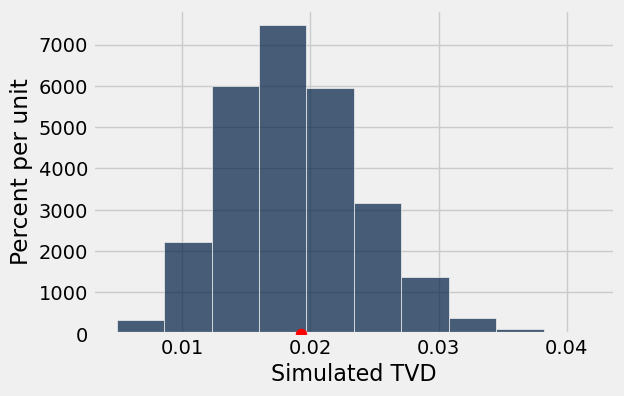

```python
Table().with_column('Simulated TVD', simulated_tvds).hist(0)
plots.scatter(observed_tvd, 0, color='red', s=60, zorder=3);
```

```python
sum(simulated_tvds >= observed_tvd) / len(simulated_tvds)
```

```
0.4395
```

Are the data consistent with the null hypothesis?

The p value of 43.95% is larger than 5%. We fail to reject the null hypothesis.

Continue at 7:56

...

### Student Survey

Load our welcome survey data from `welcome_survey_fa22.csv`.

```python
survey = Table.read_table('data/welcome_survey_fa22.csv')
survey.show(3)
```

| Section | Learning Objective | Pull Ups | DA Certificate | Born in US | Reaction Time | Work Hours per Week | Zipcode | Programming Experience | Top 3 Movie Genres | Personality | Top 2 Work Times | Data Science Work Goal | Top 2 Tutoring Days | Top 2 Tutoring Hours | Tutoring Environment | Sequence Length Memory | What approximate percentage of your life have you lived in San Francisco | COVID | Statistics Experience | Tatoos | Vision Support | Full Time Student | Course Preperation Feeling | Bachelor Degree | Registered to Vote | First Semester in College | Degree | Music Streaming | Recommend MATH 108 | … |
| --- | --- | --- | --- | --- | --- | --- | --- | --- | --- | --- | --- | --- | --- | --- | --- | --- | --- | --- | --- | --- | --- | --- | --- | --- | --- | --- | --- | --- | --- | --- |
| 70949 | 5 | 2 | 2 | nan | 300 | 15 | 94112 | 8 | Comedies, Romantic, Sci-fi & Fantasy | 2 | 6 pm - 10 pm, 10 pm - 2 am | 2 | Tuesday, Thursday | 6 am - 10 am, 6 pm - 10 pm | In person | 10 | 2 | 0 | 1 | 0 | 1 | 0 | 8 | 0 | Yes | 0 | Computer Science | Spotify | 1 | … |
| 70949 | 3 | 0 | 1 | 1 | 272 | 12 | 99999 | 1 | Anime, Comedies, Dramas | 1 | 10 am - 2 pm, 6 pm - 10 pm | 1 | Monday, Friday | 10 am - 2 pm, 2 pm - 6 pm | In person | 9 | 5 | 0 | 1 | 0 | 1 | 0 | 1 | 1 | Yes | 0 | Continuing Education | Spotify | 1 | … |
| 70949 | 3 | 1 | 0 | 0 | 257 | 2 | 99999 | 1 | Action & Adventure, Anime, Romantic | 1 | 10 am - 2 pm, 6 pm - 10 pm | 0 | Tuesday, Thursday | 10 am - 2 pm, 2 pm - 6 pm | Virtually | 14 | 5 | 999 | 4 | 0 | 1 | 1 | 4 | 0 | Yes | 0 | Psychology GRAD | YouTube Music | 1 | … |

... (49 rows omitted)

Create a reduced table by selecting the columns:

- `Bachelor Degree'`
- `'Reaction Time'` (in milliseconds)

```python
degree_reaction = survey.select('Bachelor Degree', 'Reaction Time')
degree_reaction
```

| Bachelor Degree | Reaction Time |
| --- | --- |
| 0 | 300 |
| 1 | 272 |
| 0 | 257 |
| 1 | 308 |
| 1 | 374 |
| 1 | 290 |
| 1 | 263 |
| 1 | 250 |
| 0 | 319 |
| 0 | 225 |

... (42 rows omitted)

```python
degree_reaction = degree_reaction.where('Reaction Time', are.between(20, 1000))
```

```python
degree_reaction.group(0)
```

| Bachelor Degree | count |
| --- | --- |
| 0 | 25 |
| 1 | 25 |

Determine the average reaction time for the two different groups.

```python
degree_reaction.group(0, np.mean)
```

| Bachelor Degree | Reaction Time mean |
| --- | --- |
| 0 | 279.88 |
| 1 | 316.44 |

Test whether or not there is a significant difference between the average reaction time for those that have a bachelor degree or do not.

Null hypothesis: The difference in means of these two groups is due to chance.

Alternative hypothesis: The difference in means of these two groups is not due to chance.

Test statistic: abs(mean_reaction_time_1 - mean_reaction_time_0)

Fill in the blank with "Bigger" or "Smaller":

Bigger values of the test statistic favor the alternative

Carry out an appropriate hypothesis test based on what we've covered.

```python
def compute_test_statistic(tbl):
    grouped = tbl.group('Bachelor Degree', np.average)
    avgs = grouped.column('Reaction Time average')
    return abs(avgs.item(1) - avgs.item(0))
```

```python
obs_test_stat = compute_test_statistic(degree_reaction)
obs_test_stat
```

```
36.56
```

```python
def simulate_under_null():
    random_labels = degree_reaction.sample(with_replacement=False).column('Bachelor Degree')
    relabeled_tbl = degree_reaction.with_column('Bachelor Degree', random_labels)
    return compute_test_statistic(relabeled_tbl)
```

```python
simulated_diffs = make_array()
for i in np.arange(1000):
    null_stat = simulate_under_null()
    simulated_diffs = np.append(simulated_diffs, null_stat)
```

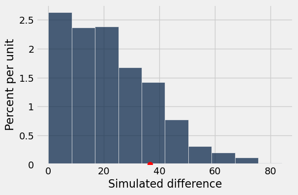

```python
Table().with_column('Simulated difference', simulated_diffs).hist(0)
plots.scatter(obs_test_stat, 0, color='red', s=60, zorder=3)
plots.show()
```

```python
p_value_2 = sum(simulated_diffs >= obs_test_stat) / len (simulated_diffs)
p_value_2
```

```
0.183
```

Are the results statistically significant?

Since the p-value is larger than 5%, these results are not significant. There is not evidence of a significant association between bach degree and reaction time.